# lab7_and_8

```python
def signif1(sample_data,background_data,feature):
    n_higgs = 100
    n_qcd = 20000
    higgs = (sum(sample_data[feature]) / sum(sample_dict[feature])) * n_higgs
    qcd = (sum(background_data[feature]) / sum(background_dict[feature])) * n_qcd

    significance = higgs / np.sqrt(qcd)
    print("Expected Significance: " + str(significance))
```

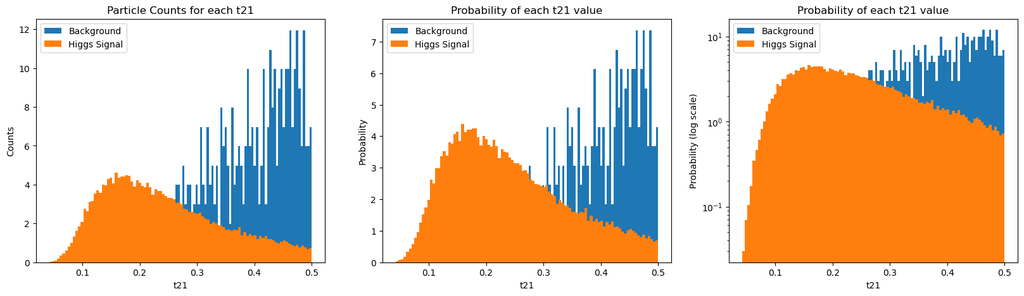

```
Expected Significance: 4.584010789439429
```

```python
cut_t21_higgs, cut_t21_qcd = cut1(cut_mass_higgs,cut_mass_qcd,0,0.50,0,0.50,'t21')
signif1(cut_t21_higgs,cut_t21_qcd,'t21')
```

Next, I will make cuts on t3

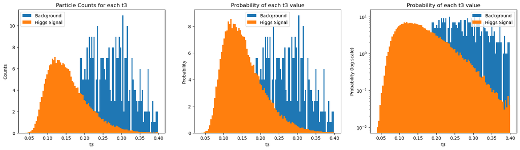

```
Expected Significance: 4.8262036738161065
```

```python
cut_t3_higgs, cut_t3_qcd = cut1(cut_t21_higgs,cut_t21_qcd,0,0.40,0,0.40,'t3')
signif1(cut_t3_higgs,cut_t3_qcd,'t3')
```

Then t2

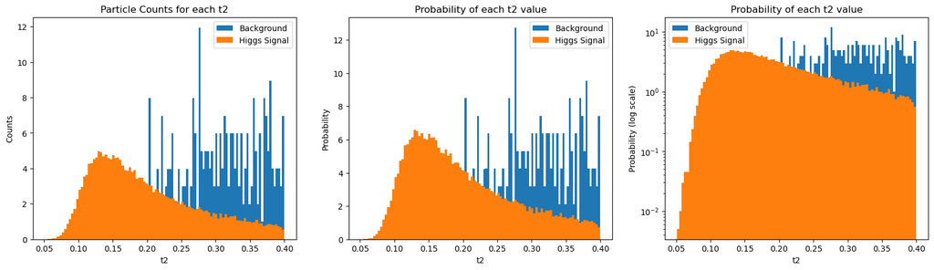

```
Expected Significance: 5.023933141212832
```

```python
cut_t2_higgs, cut_t2_qcd = cut1(cut_t3_higgs,cut_t3_qcd,0,0.40,0,0.40,'t2')
signif1(cut_t2_higgs,cut_t2_qcd,'t2')
```

Now, KtDeltaR

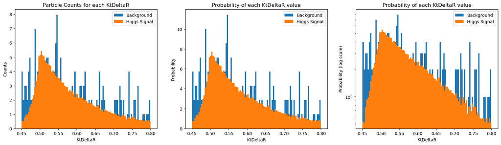

```
Expected Significance: 5.190611027920224
```

```python
cut_KtDeltaR_higgs, cut_KtDeltaR_qcd = cut1(cut_t2_higgs,cut_t2_qcd,0.45,0.80,0.45,0.80,'KtDeltaR')
signif1(cut_KtDeltaR_higgs,cut_KtDeltaR_qcd,'KtDeltaR')
```

next, angularity

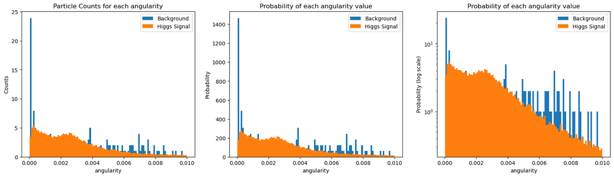

```
Expected Significance: 5.60350093514365
```

```python
cut_angle_higgs, cut_angle_qcd = cut1(cut_KtDeltaR_higgs,cut_KtDeltaR_qcd,0,0.01,0,0.01,'angularity')
signif1(cut_angle_higgs,cut_angle_qcd,'angularity')
```

next, d2

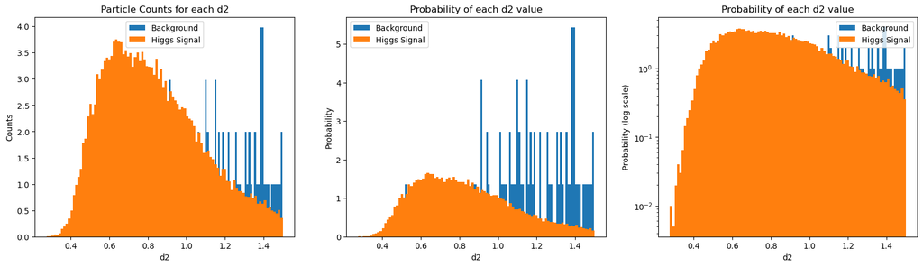

```
Expected Significance: 8.587508094837364
```

```python
cut_d2_higgs, cut_d2_qcd = cut1(cut_angle_higgs,cut_angle_qcd,0,1.5,0,1.5,'d2')
signif1(cut_d2_higgs,cut_d2_qcd,'d2')
```

This is very good significance. Let's now check the pT plot before and after event selection and compare

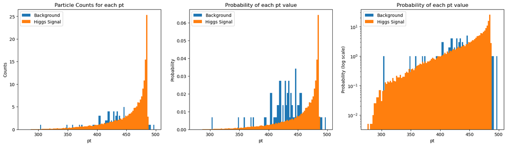

```python
#after event selection
hist('pt',cut_d2_higgs,cut_d2_qcd)
```

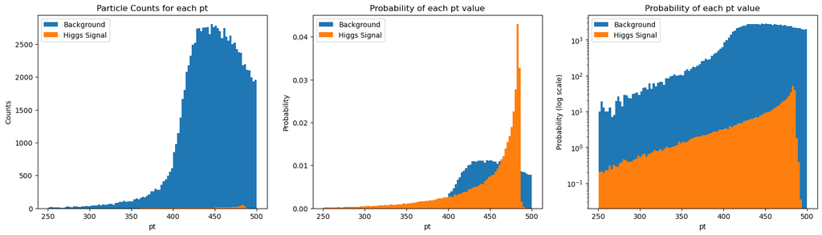

```python
#before event selection
hist('pt',sample_dict,background_dict)
```

We can see that the event selection was successful because much of the background has been eliminated while maintainting a good amount of the higgs data. Now, let's compare the significance for the pT data before/after data selection.

```python
before = signif1(sample_dict,background_dict,'pt')
after = signif1(cut_d2_higgs,cut_d2_qcd,'pt')
```

```
Expected Significance: 0.7071067811865475
Expected Significance: 9.94032437221929
```

We see that the cuts made improved the significance. Now, I will make cuts on just the transverse momentum and see what the significance is

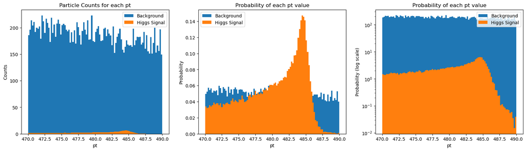

```
Expected Significance: 0.7318456444261761
```

```python
cut_pt_higgs, cut_pt_qcd = cut1(sample_dict,background_dict,470,490,470,490,'pt')
signif1(cut_pt_higgs,cut_pt_qcd,'pt')
```

There is not much room for improvement as pt is not very discriminative.

Comparing with my partner, who used the high momentum samples, my findings are different. Our statistical significances are very different. My significances are generally lower. This may be because the low momentum samples are less 'significant' meaning there are less higgs signals compared to the background as opposed to the high pt samples which has a higher ratio of higgs to qcd.

### Lab 8

```python
highlumi = pandas.read_hdf('data_highLumi_pt_250_500.h5')
highlumi.keys()
```

```
Index(['pt', 'eta', 'phi', 'mass', 'ee2', 'ee3', 'd2', 'angularity', 't1',
       't2', 't3', 't21', 't32', 'KtDeltaR'],
      dtype='object')
```

First, we add the high luminosity data to the data done in lab 7 by overlaying the observed data onto the training data. The high luminosity data represents the observed data. In other words, this is the experimental data.

```python
n_higgs_norm = 100/20100
n_qcd_norm = 20000/20100

def plot_lumi(sample_data,background_data,observed_data,feature,low_bound,high_bound):
    fig,ax = plt.subplots(1,3,figsize=(20,5))

    n_obs_norm = sum(observed_data[feature])/sum(observed_data[feature])

    n_higgs_counts,bins1 = np.histogram(sample_data[feature],bins = 100)
    n_qcd_counts,bins2 = np.histogram(background_data[feature],bins = 100)
    obs_counts,bins3 = np.histogram(observed_data[feature],bins=100)

    ax[0].hist(bins2[:-1], bins2, weights=n_qcd_counts*n_qcd_norm,label="Background",histtype='step')
    ax[0].hist(bins1[:-1], bins1, weights=n_higgs_counts*n_higgs_norm,label="Signal",histtype='step')
    ax[0].hist(bins3[:-1], bins3, weights=obs_counts*n_obs_norm,color='red',label="Observed Data",histtype='step')
    ax[0].legend(loc='best')
    ax[0].set_title('Particle Counts for each ' + feature)
    ax[0].set_xlabel(feature)
    ax[0].set_ylabel('Counts')

    ax[1].hist(bins2[:-1], bins2, weights=n_qcd_counts*n_qcd_norm,density=True,label="Background",histtype='step')
    ax[1].hist(bins1[:-1], bins1, weights=n_higgs_counts*n_higgs_norm,density=True,label="Signal",histtype='step')
    ax[1].hist(bins3[:-1], bins3, weights=obs_counts*n_obs_norm,density=True,color='red',label="Observed Data",histtype='step')
    ax[1].legend(loc='best')
    ax[1].set_xlabel(feature)
    ax[1].set_ylabel('Probability')
    ax[1].set_title('Probability of each ' + feature + ' value')

    ax[2].hist(bins2[:-1], bins2, weights=n_qcd_counts*n_qcd_norm,label="Background",histtype='step')
    ax[2].hist(bins1[:-1], bins1, weights=n_higgs_counts*n_higgs_norm,label="Signal",histtype='step')
    ax[2].hist(bins3[:-1], bins3, weights=obs_counts*n_obs_norm,color='red',label="Observed Data",histtype='step')
    ax[2].set_yscale('log')
    ax[2].legend(loc='best')
    ax[2].set_ylabel('Probability (log scale)')
    ax[2].set_title('Probability of each ' + feature + ' value')
    ax[2].set_xlabel(feature)

    plt.show()
```

```python
n_higgs_norm = 100/20100
n_qcd_norm = 20000/20100

def cut_lumi(sample_data,background_data,observed_data,feature,low_bound,high_bound):
    fig,ax = plt.subplots(1,3,figsize=(20,5))

    cut_lumi = observed_data[observed_data[feature]>low_bound]
    cut_lumi = cut_lumi[cut_lumi[feature]<high_bound]
    n_obs_norm = sum(observed_data[feature])/sum(observed_data[feature])

    cut_higgs = sample_data[sample_data[feature]>low_bound]
    cut_qcd = background_data[background_data[feature]>low_bound]

    cut_higgs = cut_higgs[cut_higgs[feature]<high_bound]
    cut_qcd = cut_qcd[cut_qcd[feature]<high_bound]

    n_higgs_counts,bins1 = np.histogram(cut_higgs[feature],bins = 100)
    n_qcd_counts,bins2 = np.histogram(cut_qcd[feature],bins = 100)
    obs_counts,bins3 = np.histogram(cut_lumi[feature],bins=100)

    ax[0].hist(bins2[:-1], bins2, weights=n_qcd_counts*n_qcd_norm,label="Background",histtype='step')
    ax[0].hist(bins1[:-1], bins1, weights=n_higgs_counts*n_higgs_norm,label="Signal",histtype='step')
    ax[0].hist(bins3[:-1], bins3, weights=obs_counts*n_obs_norm,color='red',label="Observed Data",histtype='step')
    ax[0].legend(loc='best')
    ax[0].set_title('Particle Counts for each ' + feature)
    ax[0].set_xlabel(feature)
    ax[0].set_ylabel('Counts')

    ax[1].hist(bins2[:-1], bins2, weights=n_qcd_counts*n_qcd_norm,density=True,label="Background",histtype='step')
    ax[1].hist(bins1[:-1], bins1, weights=n_higgs_counts*n_higgs_norm,density=True,label="Signal",histtype='step')
    ax[1].hist(bins3[:-1], bins3, weights=obs_counts*n_obs_norm,density=True,color='red',label="Observed Data",histtype='step')
    ax[1].legend(loc='best')
    ax[1].set_xlabel(feature)
    ax[1].set_ylabel('Probability')
    ax[1].set_title('Probability of each ' + feature + ' value')

    ax[2].hist(bins2[:-1], bins2, weights=n_qcd_counts*n_qcd_norm,label="Background",histtype='step')
    ax[2].hist(bins1[:-1], bins1, weights=n_higgs_counts*n_higgs_norm,label="Signal",histtype='step')
    ax[2].hist(bins3[:-1], bins3, weights=obs_counts*n_obs_norm,color='red',label="Observed Data",histtype='step')
    ax[2].legend(loc='best')
    ax[2].set_yscale('log')
    ax[2].set_ylabel('Probability (log scale)')
    ax[2].set_title('Probability of each ' + feature + ' value')
    ax[2].set_xlabel(feature)

    plt.show()
    return cut_higgs, cut_qcd, cut_lumi
```

```python
def lumi_sig(cut_higgs,cut_qcd,cut_lumi,feature,lumi):
    n_higgs = 100
    n_qcd = 20000
    higgs = (sum(cut_higgs[feature]) / sum(sample_dict[feature])) * n_higgs
    lumi = (sum(cut_lumi[feature]) / sum(lumi[feature])) * n_qcd

    significance = higgs / np.sqrt(lumi)
    print("Observed Significance: " + str(significance))
```

I will overlap the observed data on the sample data with optimal cuts and compare the significance starting with the mass parameter. In each group, the top row of plots represents the training data overlapped with the observed data without event selection and the second row involved the same types of plots with the event selection. This is done for all parameters used in lab 7.

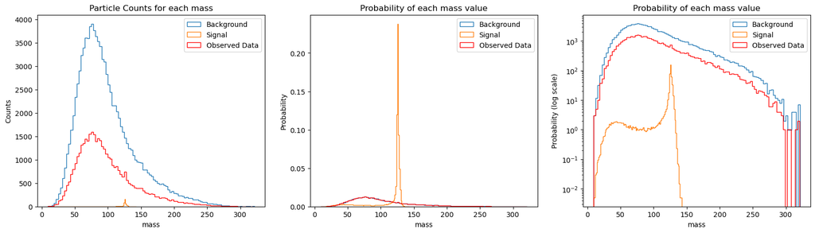

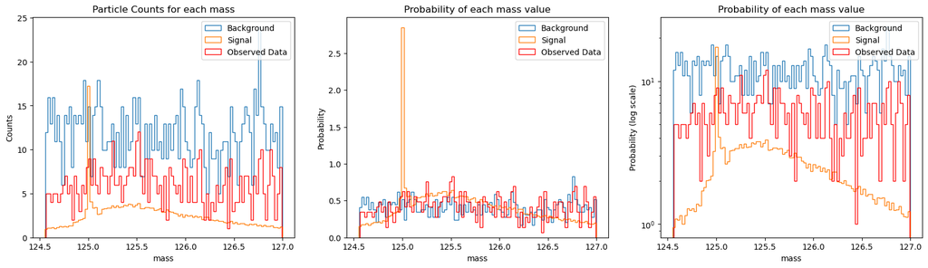

```
Expected Significance: 3.1065303151335293
Observed Significance: 2.7934212597565553
```

```python
plot_lumi(sample_dict,background_dict,highlumi,'mass',0,500)
cut_mass_higgs, cut_mass_qcd, cut_mass_highlumi = cut_lumi(sample_dict,background_dict,highlumi,'mass',124.55,127)
signif1(cut_mass_higgs,cut_mass_qcd,'mass')
lumi_sig(cut_mass_higgs,cut_mass_qcd, cut_mass_highlumi,'mass',highlumi)
```

Next, I will do this with the same parameters used in the lab 7 to improve the significance and compare with the significance used observed in lab 7.

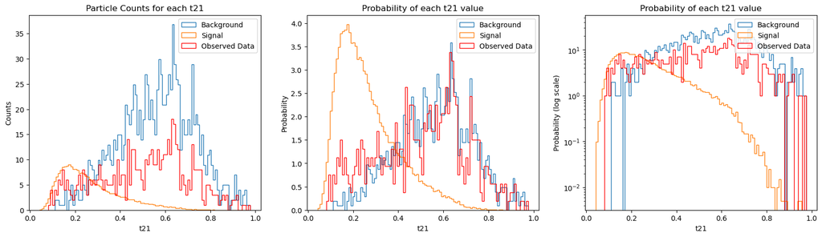

```python
plot_lumi(cut_mass_higgs,cut_mass_qcd,cut_mass_highlumi,'t21',0,500)
cut_t21_higgs, cut_t21_qcd, cut_t21_highlumi = cut_lumi(cut_mass_higgs,cut_mass_qcd,cut_mass_highlumi,'t21',0,0.50)
signif1(cut_t21_higgs,cut_t21_qcd,'t21')
lumi_sig(cut_t21_higgs,cut_t21_qcd, cut_t21_highlumi,'t21',highlumi)
```

[output not shown]